# 3. Exponential Population

- Show All Code
- Hide All Code
- View Source

Strong right skew, and a direct test of the ‘n = 30’ rule

Author

Richa Vakharia

```r
source("R/clt_helpers.R")
rate <- 1
gen_exp <- function(k) rexp(k, rate = rate)
```

## 1 What population am I sampling from?

Exponential with rate $\lambda = 1$, generated with `rexp()`. It’s continuous, can’t go below 0, and has a long **right tail**. It’s the kind of shape you see for waiting times or wait-until-failure times.

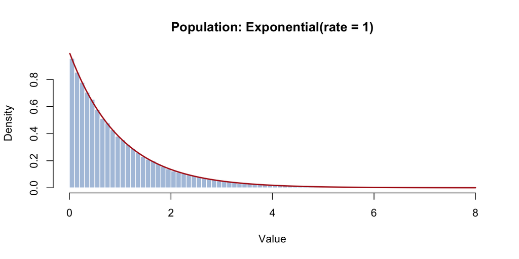

```r
plot_population(gen_exp, "Population: Exponential(rate = 1)", xlim = c(0, 8))
curve(dexp(x, rate), add = TRUE, col = "firebrick", lwd = 2)
```

| Quantity | Theoretical value |
| --- | --- |
| Mean $\mu = 1/\lambda$ | 1 |
| SD $\sigma = 1/\lambda$ | 1 |
| Skewness | 2 |
| Excess kurtosis | 6 |
| $SE(\bar X)$ | $1/\sqrt{n}$ |

```r
mu <- 1 / rate; sigma <- 1 / rate; g1 <- 2; g2 <- 6
```

## 2 What did I expect?

This is the case where I think $n = 30$ will **not** be enough. The skewness of $\bar X$ is $2/\sqrt{n}$, so at $n = 30$ it’s still $2/\sqrt{30} \approx 0.37$, which is above my 0.25 cutoff. Solving $2/\sqrt n < 0.25$:

```r
predicted_n(g1, g2)
```

```
  from_skewness from_kurtosis prediction
1            64            12         64
```

My prediction: skewness is the bottleneck, and the answer lands somewhere around $n = 64$.

## 3 Which sample sizes did I investigate?

The standard grid from 1 to 500, with $B = 10,000$ repetitions. The grid is dense between 30 and 100 (30, 35, 40, 45, 50, 60, 70, 80, 90, 100), which is exactly where I expected the cutoff to be, so I can pin it down.

## 4 Simulation

```r
sweep  <- run_sweep(function(n) simulate_means(gen_exp, n, B), mu = mu, sigma = sigma)
tab    <- sweep$table
n_star <- chosen_n(tab)
show_table(tab)
```

| n | sim_mean | theo_mean | sim_se | theo_se | se_ratio | skewness | ex_kurt | qq_cor | qq_dist | shapiro_p | normal_enough |
| --- | --- | --- | --- | --- | --- | --- | --- | --- | --- | --- | --- |
| 1 | 1.0100 | 1 | 1.01200 | 1.00000 | 1.0120 | 1.9780 | 5.65900 | 0.9027 | 0.26510 | < 1e-04 | FALSE |
| 2 | 0.9967 | 1 | 0.69750 | 0.70710 | 0.9865 | 1.4400 | 3.33700 | 0.9483 | 0.18680 | < 1e-04 | FALSE |
| 3 | 0.9964 | 1 | 0.57900 | 0.57740 | 1.0030 | 1.2020 | 2.38100 | 0.9626 | 0.16220 | < 1e-04 | FALSE |
| 4 | 1.0050 | 1 | 0.50720 | 0.50000 | 1.0140 | 1.0520 | 1.96500 | 0.9717 | 0.13510 | < 1e-04 | FALSE |
| 5 | 1.0090 | 1 | 0.44870 | 0.44720 | 1.0030 | 0.9218 | 1.36000 | 0.9775 | 0.12540 | < 1e-04 | FALSE |
| 6 | 0.9992 | 1 | 0.40170 | 0.40820 | 0.9840 | 0.7470 | 0.65350 | 0.9838 | 0.11430 | < 1e-04 | FALSE |
| 8 | 0.9940 | 1 | 0.35100 | 0.35360 | 0.9928 | 0.7263 | 0.77030 | 0.9855 | 0.10280 | < 1e-04 | FALSE |
| 10 | 0.9983 | 1 | 0.31290 | 0.31620 | 0.9895 | 0.6241 | 0.50620 | 0.9890 | 0.09148 | < 1e-04 | FALSE |
| 12 | 1.0050 | 1 | 0.29180 | 0.28870 | 1.0110 | 0.5600 | 0.40720 | 0.9911 | 0.08033 | < 1e-04 | FALSE |
| 15 | 1.0020 | 1 | 0.26010 | 0.25820 | 1.0070 | 0.5802 | 0.55380 | 0.9909 | 0.08127 | < 1e-04 | FALSE |
| 20 | 0.9964 | 1 | 0.22100 | 0.22360 | 0.9884 | 0.4835 | 0.40840 | 0.9935 | 0.06593 | < 1e-04 | FALSE |
| 25 | 1.0000 | 1 | 0.19910 | 0.20000 | 0.9953 | 0.4073 | 0.28880 | 0.9954 | 0.05647 | < 1e-04 | FALSE |
| 30 | 0.9991 | 1 | 0.18230 | 0.18260 | 0.9985 | 0.4109 | 0.32080 | 0.9953 | 0.05098 | < 1e-04 | FALSE |
| 35 | 0.9983 | 1 | 0.16660 | 0.16900 | 0.9858 | 0.3220 | 0.12260 | 0.9970 | 0.04612 | < 1e-04 | FALSE |
| 40 | 1.0000 | 1 | 0.16010 | 0.15810 | 1.0130 | 0.3218 | 0.12560 | 0.9970 | 0.04706 | < 1e-04 | FALSE |
| 45 | 1.0020 | 1 | 0.15050 | 0.14910 | 1.0100 | 0.3301 | 0.27230 | 0.9969 | 0.04448 | < 1e-04 | FALSE |
| 50 | 1.0000 | 1 | 0.14190 | 0.14140 | 1.0030 | 0.2732 | 0.17730 | 0.9979 | 0.03765 | < 1e-04 | FALSE |
| 60 | 0.9998 | 1 | 0.12760 | 0.12910 | 0.9884 | 0.2838 | 0.10300 | 0.9977 | 0.04366 | < 1e-04 | FALSE |
| 70 | 1.0020 | 1 | 0.11770 | 0.11950 | 0.9851 | 0.2017 | -0.01744 | 0.9988 | 0.03110 | < 1e-04 | TRUE |
| 80 | 0.9978 | 1 | 0.11260 | 0.11180 | 1.0070 | 0.1869 | 0.02410 | 0.9990 | 0.02625 | < 1e-04 | TRUE |
| 90 | 1.0010 | 1 | 0.10510 | 0.10540 | 0.9973 | 0.2142 | 0.04740 | 0.9986 | 0.02904 | < 1e-04 | TRUE |
| 100 | 1.0010 | 1 | 0.10040 | 0.10000 | 1.0040 | 0.2213 | 0.05044 | 0.9986 | 0.03286 | < 1e-04 | TRUE |
| 125 | 1.0010 | 1 | 0.08867 | 0.08944 | 0.9913 | 0.1638 | 0.08462 | 0.9992 | 0.02069 | < 1e-04 | TRUE |
| 150 | 1.0000 | 1 | 0.08196 | 0.08165 | 1.0040 | 0.1784 | 0.04405 | 0.9991 | 0.02605 | < 1e-04 | TRUE |
| 200 | 1.0010 | 1 | 0.07010 | 0.07071 | 0.9914 | 0.1432 | 0.02720 | 0.9993 | 0.01764 | 0.00021 | TRUE |
| 300 | 0.9990 | 1 | 0.05753 | 0.05774 | 0.9965 | 0.1362 | 0.04708 | 0.9994 | 0.01909 | 0.00033 | TRUE |
| 500 | 0.9999 | 1 | 0.04493 | 0.04472 | 1.0050 | 0.1057 | 0.06397 | 0.9996 | 0.01560 | 0.02887 | TRUE |

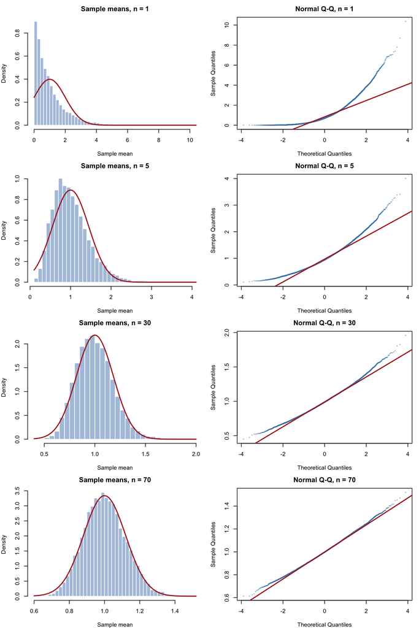

```r
plot_sampling(sweep, c(1, 5, 30, n_star), mu = mu, sigma = sigma)
```

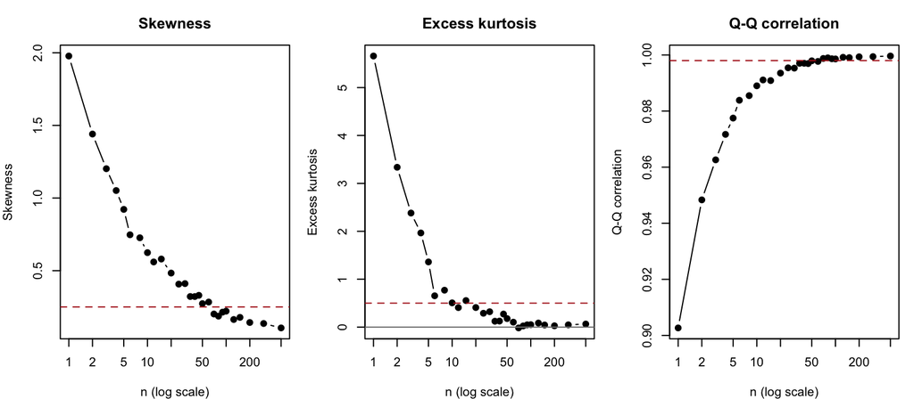

```r
plot_convergence(tab)
```

I also compared the simulated skewness to the theory curve $2/\sqrt n$:

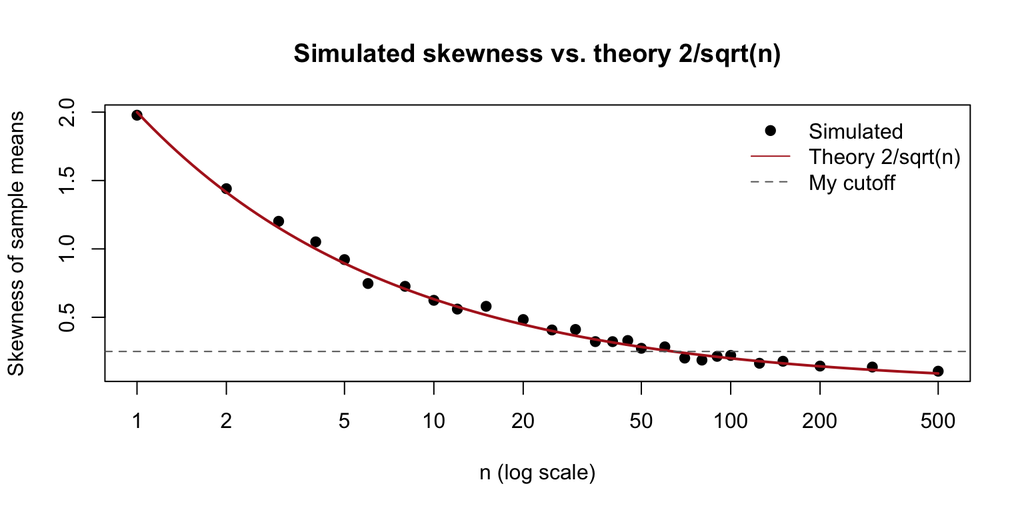

```r
plot(tab$n, tab$skewness, log = "x", pch = 19,
     xlab = "n (log scale)", ylab = "Skewness of sample means",
     main = "Simulated skewness vs. theory 2/sqrt(n)")
curve(2 / sqrt(x), add = TRUE, col = "firebrick", lwd = 2)
abline(h = skew_cut, lty = 2, col = "gray40")
legend("topright", c("Simulated", "Theory 2/sqrt(n)", "My cutoff"),
       col = c("black", "firebrick", "gray40"), pch = c(19, NA, NA),
       lty = c(NA, 1, 2), bty = "n")
```

## 5 Theory vs. simulation

- **Mean:** every simulated mean is within 0.01 of 1.
- **Standard error:** simulated SE / $(1/\sqrt n)$ ranged from 0.984 to 1.014. So the SE formula works at every $n$, even $n = 1$ where the shape is nowhere near normal. **The formula for the SE being right does not mean the shape is normal.** Those are two different questions.
- **Shape:** the simulated skewness follows $2/\sqrt n$ really closely.

At $n = 30$ specifically:

```r
knitr::kable(signif(tab[tab$n == 30, c("n", "skewness", "ex_kurt", "qq_cor", "shapiro_p")], 3))
```

|  | n | skewness | ex_kurt | qq_cor | shapiro_p |
| --- | --- | --- | --- | --- | --- |
| 13 | 30 | 0.411 | 0.321 | 0.995 | 0 |

## 6 When is it approximately normal?

$$\boxed{n = 70}$$

That’s very close to my prediction of 64. At $n = 70$ the skewness drops to 0.202 and the Q-Q correlation reaches 0.9988. Kurtosis was never the bottleneck: it passed my cutoff early, just like theory said. You can still see a slight upward bend at the right end of the Q-Q plot at $n = 30$, which is the leftover right skew.

## 7 Reproducibility experiment

The assignment asks what happens with a different seed. I reran the exact same sweep, but with seeds based on 1234 instead of my ID:

```r
sweep_alt <- run_sweep(function(n) simulate_means(gen_exp, n, B, seed = 1234 + n),
                       mu = mu, sigma = sigma)
tab_alt <- sweep_alt$table
n_star_alt <- chosen_n(tab_alt)

compare <- data.frame(
  n = tab$n,
  skew_my_seed  = round(tab$skewness, 3),
  skew_alt_seed = round(tab_alt$skewness, 3),
  pass_my_seed  = tab$normal_enough,
  pass_alt_seed = tab_alt$normal_enough
)
knitr::kable(compare[compare$n >= 30 & compare$n <= 150, ], row.names = FALSE)
```

| n | skew_my_seed | skew_alt_seed | pass_my_seed | pass_alt_seed |
| --- | --- | --- | --- | --- |
| 30 | 0.411 | 0.373 | FALSE | FALSE |
| 35 | 0.322 | 0.370 | FALSE | FALSE |
| 40 | 0.322 | 0.314 | FALSE | FALSE |
| 45 | 0.330 | 0.317 | FALSE | FALSE |
| 50 | 0.273 | 0.304 | FALSE | FALSE |
| 60 | 0.284 | 0.233 | FALSE | TRUE |
| 70 | 0.202 | 0.235 | TRUE | TRUE |
| 80 | 0.187 | 0.244 | TRUE | TRUE |
| 90 | 0.214 | 0.243 | TRUE | TRUE |
| 100 | 0.221 | 0.241 | TRUE | TRUE |
| 125 | 0.164 | 0.150 | TRUE | TRUE |
| 150 | 0.178 | 0.107 | TRUE | TRUE |

- **Did the exact results change?** Yes. Every number changes a little, because they’re different random draws.
- **Did my conclusion change?** With my seed the answer is $n = 70$ and with the other seed it’s $n = 60$. Close, but not identical, because near the cutoff the skewness is only slightly above or below 0.25, so noise can tip it one way or the other. The big conclusion (somewhere around 60 to 80, definitely not 30) doesn’t change.

What this tells me about Monte Carlo: the seed makes the *exact* numbers reproducible, but the *conclusion* should be robust to the seed. If changing the seed flipped my conclusion completely, it would mean $B$ is too small or my cutoff is right on the edge of the noise.

## 8 What surprised me?

How well the theory predicted the simulation. I expected “about 60-ish” and the simulated skewness sat right on top of the $2/\sqrt n$ curve. I was also surprised that the SE formula was accurate at $n = 1$, when the histogram of means is literally just the exponential distribution. It made it clear that the CLT is a statement about **shape**, not about the mean or the SE.

```r
save_results("Exponential", tab, n_star,
             "Skewness 2/sqrt(n) is the bottleneck; n = 30 is not enough")
```